# DATASCI 350 - Data Science Computing

## Assignment 02: Using the Command Line Interface

In this assignment, you will practice using various command line interface (CLI) commands covered in the lecture. You will complete a series of tasks and submit your work either as a Jupyter Notebook or a PDF document with screenshots.

### Instructions

1. Open your terminal or command prompt.
2. Navigate to a directory where you want to create a new folder for this assignment using the `cd` command.
3. Create a new directory called "cli_assignment" using the `mkdir` command.
4. Change into the "cli_assignment" directory using the `cd` command.
5. Complete the following tasks:

   a. Use the `ls` command to list the contents of the current directory. Take a screenshot of the output.

   b. Create a new file called "README.md" using the `touch` command. Use the `ls` command again to verify that the file was created. Take a screenshot of the output.

   c. Use the `echo` command to append the text "# CLI Assignment" to the "README.md" file. Use the `cat` command to display the contents of the file. Take a screenshot of the output.

   d. Create a new directory called "data" inside the "cli_assignment" directory using the `mkdir` command. Use the `ls` command with the `-l` flag to display the contents of the "cli_assignment" directory in long format. Take a screenshot of the output.

   e. Use the `man` command to display the manual page for the `ls` command. Scroll through the manual page and find the flag that allows you to display hidden files. Use the `ls` command with this flag to display all files, including hidden files, in the current directory. Take a screenshot of the output.

### Submission

If you are using Jupyter Notebooks:

- Create a new Jupyter Notebook in the "cli_assignment" directory.
- For each task, create a new code cell and execute the required commands.
- After each task, create a new markdown cell and include the screenshot of the output.
- Save the Jupyter Notebook and submit it.

If you are using a PDF document:

- Open a new document in your preferred word processor.
- For each task, include the command(s) you used and the corresponding screenshot of the output.
- Save the document as a PDF and submit it.

This assignment will help you become more comfortable with navigating the file system, creating and manipulating files and directories, and using the `man` command to explore command options. Good luck!

### How to run command line commands in a Jupyter Notebook

There are several ways to run command line commands in Jupyter. You can use the following approaches:

1. Using the `!` prefix:
   - By prefixing a command with `!`, Jupyter Notebook will execute it as a shell command.
   - For example, to list the files in the current directory, you can use: `!ls`
   - This will execute the `ls` command and display the output in the notebook cell.

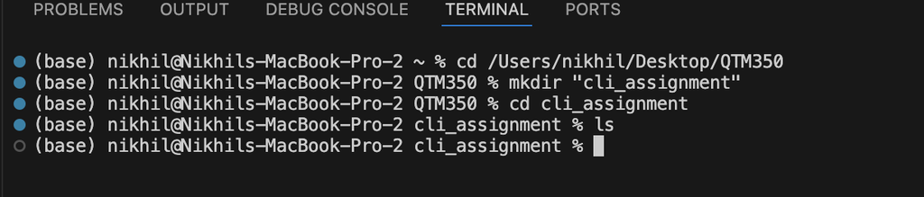

```python
%cd ~
%cd /Users/nikhil/Desktop/QTM350
%mkdir "cli_assignment"
%cd cli_assignment

# task 1:
!ls
```

```
/Users/nikhil
/Users/nikhil/Desktop/QTM350
mkdir: cli_assignment: File exists
/Users/nikhil/Desktop/QTM350/cli_assignment
```

```python
# task 2:
!touch README.md
!ls
```

```
README.md
```

```python
# task 3:
!echo "cli_assignment" >> README.md
!cat README.md
```

```
cli_assignment
cli_assignment
cli_assignment
```

```python
# task 4:
%pwd
!mkdir data
!ls -l
```

```
mkdir: data: File exists
total 8
-rw-r--r--  1 nikhil  staff  45 Feb  2 18:04 README.md
drwxr-xr-x  2 nikhil  staff  64 Feb  2 18:05 data
```

```python
# task 5:
# the entire manual code will only run in the terminal
!ls -a
```

```
.         ..        README.md data
```